# Kansara_Vedant_Time_Series_Decomposition

```python
import numpy as np
import pandas as pd
import matplotlib.pyplot as plt

import seaborn as sns
```

```python
import statsmodels.api as sm
```

**Reading data**

```python
lf = pd.read_csv('sp500_stock_20_22_close_with_sector_long_format.csv')
```

```python
wf = pd.read_csv('sp500_stock_20_22_close_with_sector_wide_format.csv')
```

```python
wf.head()
```

|  | symbol | sector | day_001 | day_002 | day_003 | day_004 | day_005 | day_006 | day_007 | day_008 | ... | day_747 | day_748 | day_749 | day_750 | day_751 | day_752 | day_753 | day_754 | day_755 | day_756 |
| --- | --- | --- | --- | --- | --- | --- | --- | --- | --- | --- | --- | --- | --- | --- | --- | --- | --- | --- | --- | --- | --- |
| 0 | A | Health Care | 85.949997 | 84.570000 | 84.820000 | 85.080002 | 85.919998 | 87.269997 | 87.589996 | 87.459999 | ... | 149.300003 | 146.949997 | 147.929993 | 150.089996 | 149.009995 | 149.229996 | 149.550003 | 148.089996 | 151.089996 | 149.649994 |
| 1 | AAL | Industrials | 29.090000 | 27.650000 | 27.320000 | 27.219999 | 27.840000 | 27.950001 | 27.320000 | 27.389999 | ... | 12.810000 | 12.480000 | 12.530000 | 13.030000 | 12.560000 | 12.710000 | 12.530000 | 12.320000 | 12.700000 | 12.720000 |
| 2 | AAP | Consumer Discretionary | 159.410004 | 159.419998 | 156.800003 | 154.940002 | 153.160004 | 152.869995 | 149.009995 | 145.259995 | ... | 140.160004 | 140.899994 | 139.380005 | 142.289993 | 142.080002 | 143.279999 | 145.020004 | 145.300003 | 146.309998 | 147.029999 |
| 3 | AAPL | Information Technology | 75.087502 | 74.357498 | 74.949997 | 74.597504 | 75.797501 | 77.407501 | 77.582497 | 79.239998 | ... | 134.509995 | 132.369995 | 132.300003 | 135.449997 | 132.229996 | 131.860001 | 130.029999 | 126.040001 | 129.610001 | 129.929993 |
| 4 | ABBV | Health Care | 89.550003 | 88.699997 | 89.400002 | 88.889999 | 89.519997 | 90.209999 | 89.059998 | 88.519997 | ... | 160.479996 | 161.490005 | 160.580002 | 162.210007 | 163.270004 | 163.100006 | 162.990005 | 162.229996 | 162.559998 | 161.610001 |

5 rows × 758 columns

```python
lf.info()
```

```
<class 'pandas.core.frame.DataFrame'>
RangeIndex: 378000 entries, 0 to 377999
Data columns (total 5 columns):
 #   Column      Non-Null Count   Dtype
---  ------      --------------   -----
 0   symbol      378000 non-null  object
 1   close       378000 non-null  float64
 2   date        378000 non-null  object
 3   day_number  378000 non-null  object
 4   sector      378000 non-null  object
dtypes: float64(1), object(4)
memory usage: 14.4+ MB
```

##### Adding date column

```python
lf['date_dt'] = pd.to_datetime( lf.date )
```

##### Adding rel close price

```python
first_df =  lf.groupby('symbol').\
            aggregate(min_date = ('date_dt', 'min'),
                      first_close = ('close', 'first')).\
            reset_index()
```

```python
first_df.head()
```

|  | symbol | min_date | first_close |
| --- | --- | --- | --- |
| 0 | A | 2020-01-02 | 85.949997 |
| 1 | AAL | 2020-01-02 | 29.090000 |
| 2 | AAP | 2020-01-02 | 159.410004 |
| 3 | AAPL | 2020-01-02 | 75.087502 |
| 4 | ABBV | 2020-01-02 | 89.550003 |

**Adding the first close column to original long format dataframe**

```python
lf = lf.set_index('symbol').join(first_df.set_index('symbol'), on='symbol', how='left')
```

```python
lf = lf.reset_index()
```

```python
lf.head()
```

|  | symbol | close | date | day_number | sector | date_dt | min_date | first_close |
| --- | --- | --- | --- | --- | --- | --- | --- | --- |
| 0 | AAPL | 75.087502 | 2020-01-02 | day_001 | Information Technology | 2020-01-02 | 2020-01-02 | 75.087502 |
| 1 | AAPL | 74.357498 | 2020-01-03 | day_002 | Information Technology | 2020-01-03 | 2020-01-02 | 75.087502 |
| 2 | AAPL | 74.949997 | 2020-01-06 | day_003 | Information Technology | 2020-01-06 | 2020-01-02 | 75.087502 |
| 3 | AAPL | 74.597504 | 2020-01-07 | day_004 | Information Technology | 2020-01-07 | 2020-01-02 | 75.087502 |
| 4 | AAPL | 75.797501 | 2020-01-08 | day_005 | Information Technology | 2020-01-08 | 2020-01-02 | 75.087502 |

**Adding the rel_close column**

```python
lf['rel_close'] = (lf.close - lf.first_close) / lf.first_close
```

```python
lf.head()
```

|  | symbol | close | date | day_number | sector | date_dt | min_date | first_close | rel_close |
| --- | --- | --- | --- | --- | --- | --- | --- | --- | --- |
| 0 | AAPL | 75.087502 | 2020-01-02 | day_001 | Information Technology | 2020-01-02 | 2020-01-02 | 75.087502 | 0.000000 |
| 1 | AAPL | 74.357498 | 2020-01-03 | day_002 | Information Technology | 2020-01-03 | 2020-01-02 | 75.087502 | -0.009722 |
| 2 | AAPL | 74.949997 | 2020-01-06 | day_003 | Information Technology | 2020-01-06 | 2020-01-02 | 75.087502 | -0.001831 |
| 3 | AAPL | 74.597504 | 2020-01-07 | day_004 | Information Technology | 2020-01-07 | 2020-01-02 | 75.087502 | -0.006526 |
| 4 | AAPL | 75.797501 | 2020-01-08 | day_005 | Information Technology | 2020-01-08 | 2020-01-02 | 75.087502 | 0.009456 |

**Creating a wide format data with relative closing price**

```python
wf_final = lf.pivot(index='symbol', columns='date_dt', values='rel_close').reset_index()
```

```python
wf_final.columns.values[1:] = ['day_' + str(d).zfill(3) for d in range(1,756+1)]
```

```python
wf_final['sector'] = wf.sector
```

```python
wf_final.head()
```

| date_dt | symbol | day_001 | day_002 | day_003 | day_004 | day_005 | day_006 | day_007 | day_008 | day_009 | ... | day_748 | day_749 | day_750 | day_751 | day_752 | day_753 | day_754 | day_755 | day_756 | sector |
| --- | --- | --- | --- | --- | --- | --- | --- | --- | --- | --- | --- | --- | --- | --- | --- | --- | --- | --- | --- | --- | --- |
| 0 | A | 0.0 | -0.016056 | -0.013147 | -0.010122 | -0.000349 | 0.015358 | 0.019081 | 0.017568 | 0.023735 | ... | 0.709715 | 0.721117 | 0.746248 | 0.733682 | 0.736242 | 0.739965 | 0.722978 | 0.757883 | 0.741129 | Health Care |
| 1 | AAL | 0.0 | -0.049502 | -0.060846 | -0.064283 | -0.042970 | -0.039189 | -0.060846 | -0.058439 | -0.053627 | ... | -0.570987 | -0.569268 | -0.552080 | -0.568237 | -0.563080 | -0.569268 | -0.576487 | -0.563424 | -0.562736 | Industrials |
| 2 | AAP | 0.0 | 0.000063 | -0.016373 | -0.028041 | -0.039207 | -0.041026 | -0.065241 | -0.088765 | -0.065931 | ... | -0.116116 | -0.125651 | -0.107396 | -0.108713 | -0.101186 | -0.090270 | -0.088514 | -0.082178 | -0.077661 | Consumer Discretionary |
| 3 | AAPL | 0.0 | -0.009722 | -0.001831 | -0.006526 | 0.009456 | 0.030897 | 0.033228 | 0.055302 | 0.041052 | ... | 0.762877 | 0.761944 | 0.803895 | 0.761012 | 0.756085 | 0.731713 | 0.678575 | 0.726119 | 0.730381 | Information Technology |
| 4 | ABBV | 0.0 | -0.009492 | -0.001675 | -0.007370 | -0.000335 | 0.007370 | -0.005472 | -0.011502 | -0.015075 | ... | 0.803350 | 0.793188 | 0.811390 | 0.823227 | 0.821329 | 0.820100 | 0.811614 | 0.815299 | 0.804690 | Health Care |

5 rows × 758 columns

**Creating a dataframe with rel_close_price grouped by sector**

```python
sec_df = lf.groupby(['sector', 'date_dt']).\
    aggregate(sec_rel_close = ('rel_close', 'mean')).\
    reset_index()
```

```python
sec_df
```

|  | sector | date_dt | sec_rel_close |
| --- | --- | --- | --- |
| 0 | Communication Services | 2020-01-02 | 0.000000 |
| 1 | Communication Services | 2020-01-03 | -0.003841 |
| 2 | Communication Services | 2020-01-06 | 0.002534 |
| 3 | Communication Services | 2020-01-07 | 0.003866 |
| 4 | Communication Services | 2020-01-08 | 0.009071 |
| ... | ... | ... | ... |
| 8311 | Utilities | 2022-12-23 | 0.073527 |
| 8312 | Utilities | 2022-12-27 | 0.081651 |
| 8313 | Utilities | 2022-12-28 | 0.070699 |
| 8314 | Utilities | 2022-12-29 | 0.078155 |
| 8315 | Utilities | 2022-12-30 | 0.066247 |

8316 rows × 3 columns

**Trying to time series decomposition on one sector**

```python
comm_service_df = sec_df.loc[sec_df.sector == 'Communication Services']
```

```python
comm_service_df.head()
```

|  | sector | date_dt | sec_rel_close |
| --- | --- | --- | --- |
| 0 | Communication Services | 2020-01-02 | 0.000000 |
| 1 | Communication Services | 2020-01-03 | -0.003841 |
| 2 | Communication Services | 2020-01-06 | 0.002534 |
| 3 | Communication Services | 2020-01-07 | 0.003866 |
| 4 | Communication Services | 2020-01-08 | 0.009071 |

**Making a series from the data frame for time series**

```python
comm_rel_close_series = comm_service_df.sec_rel_close.copy()
```

```python
comm_rel_close_series
```

```
0      0.000000
1     -0.003841
2      0.002534
3      0.003866
4      0.009071
         ...
751   -0.101032
752   -0.106178
753   -0.119191
754   -0.100384
755   -0.100091
Name: sec_rel_close, Length: 756, dtype: float64
```

**Setting the index of the series to data time object.**

```python
comm_rel_close_series.index = comm_service_df.date_dt.copy()
```

```python
comm_rel_close_series.index
```

```
DatetimeIndex(['2020-01-02', '2020-01-03', '2020-01-06', '2020-01-07',
               '2020-01-08', '2020-01-09', '2020-01-10', '2020-01-13',
               '2020-01-14', '2020-01-15',
               ...
               '2022-12-16', '2022-12-19', '2022-12-20', '2022-12-21',
               '2022-12-22', '2022-12-23', '2022-12-27', '2022-12-28',
               '2022-12-29', '2022-12-30'],
              dtype='datetime64[ns]', name='date_dt', length=756, freq=None)
```

```python
comm_ready = comm_rel_close_series.copy().resample('W').last()
```

```python
comm_ready
```

```
date_dt
2020-01-05   -0.003841
2020-01-12    0.003468
2020-01-19    0.034827
2020-01-26    0.002661
2020-02-02   -0.022161
                ...
2022-12-04   -0.037557
2022-12-11   -0.083824
2022-12-18   -0.106436
2022-12-25   -0.101032
2023-01-01   -0.100091
Freq: W-SUN, Name: sec_rel_close, Length: 157, dtype: float64
```

```python
from statsmodels.tsa.seasonal import STL
```

```python
lf.sector.unique()
```

```
array(['Information Technology', 'Consumer Discretionary',
       'Communication Services', 'Financials', 'Health Care', 'Energy',
       'Consumer Staples', 'Materials', 'Utilities', 'Industrials',
       'Real Estate'], dtype=object)
```

There are 11 unique sectors.

```python
sectors = ['Information Technology', 'Consumer Discretionary',
       'Communication Services', 'Financials', 'Health Care', 'Energy',
       'Consumer Staples', 'Materials', 'Utilities', 'Industrials',
       'Real Estate']
```

```python
lf.sector.unique()[0]
```

```
'Information Technology'
```

```python
sectors[0]
```

```
'Information Technology'
```

**Functtion to get time series and STL decomposition based on each sector**

```python
def my_decom(given_df, given_sec):
    res_list = []
    ready_list=[]

    ### Getting all the sereis ready for decomposition in list
    for i in range(0, len(given_sec)):
        df = given_df.loc[given_df.sector == given_sec[i]]
        sec_close_series = df.sec_rel_close.copy()
        sec_close_series.index = df.date_dt.copy()
        sec_ready_series = sec_close_series.copy().resample('W').last()
        res_list.append(sec_ready_series)

    ### Using the ready sereis to create a STL decomposition for all sectors.
    for i in range(0, len(given_sec)):
        ready_list.append( STL(res_list[i]).fit() )


    return ready_list
```

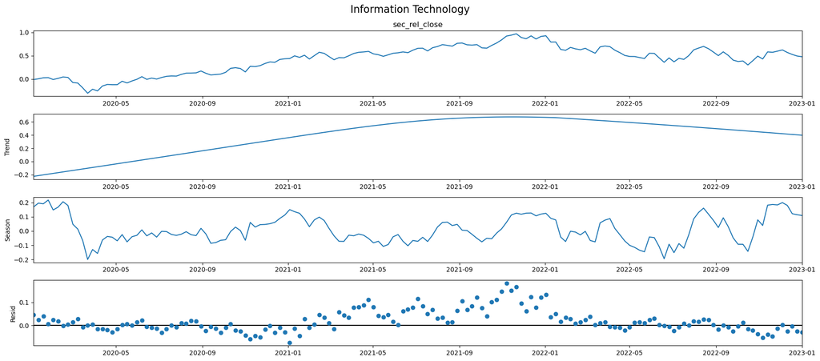

```python
plt.rcParams['figure.figsize'] = 18,8
fig = my_decom(sec_df, sectors)[0].plot().suptitle(sectors[0], fontsize=16)
plt.tight_layout()
```

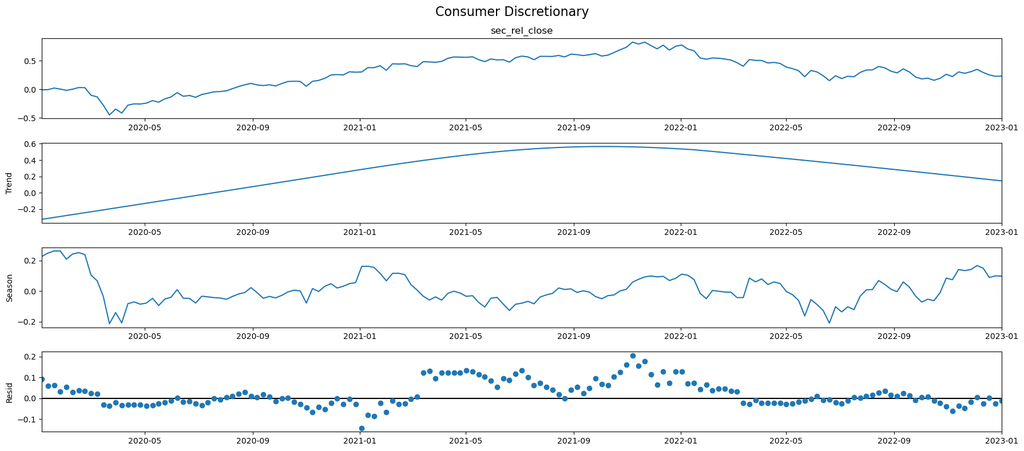

```python
fig = my_decom(sec_df, sectors)[1].plot().suptitle(sectors[1], fontsize=16)
plt.tight_layout()
```

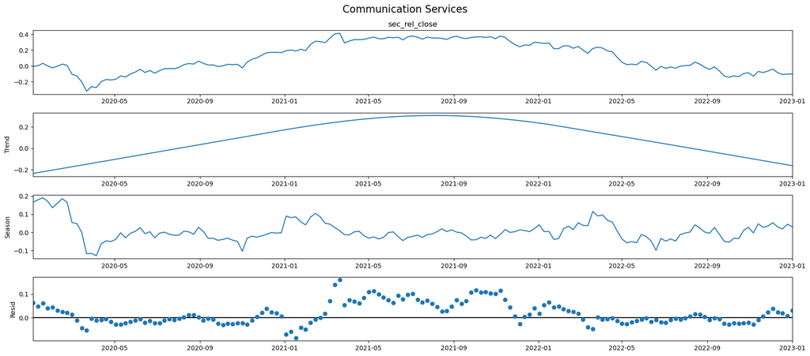

```python
fig = my_decom(sec_df, sectors)[2].plot().suptitle(sectors[2], fontsize=16)
plt.tight_layout()
```

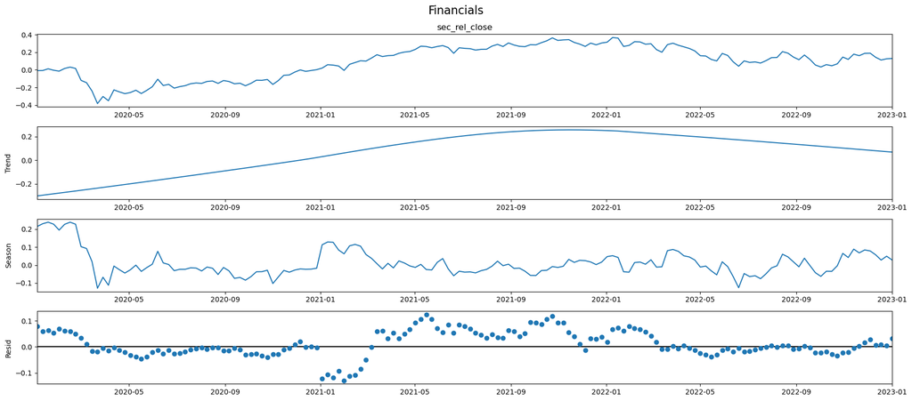

```python
fig = my_decom(sec_df, sectors)[3].plot().suptitle(sectors[3], fontsize=16)
plt.tight_layout()
```

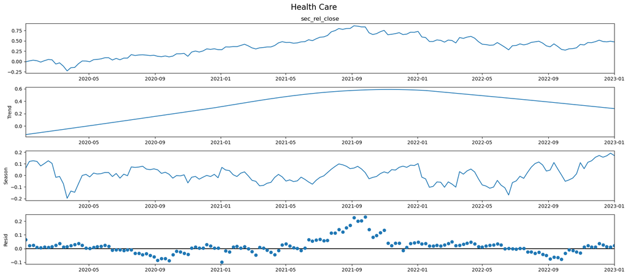

```python
fig = my_decom(sec_df, sectors)[4].plot().suptitle(sectors[4], fontsize=16)
plt.tight_layout()
```

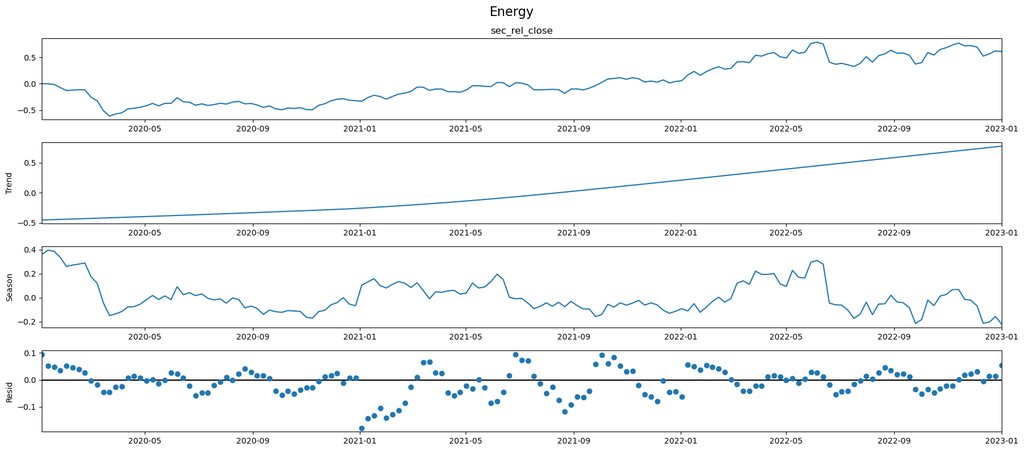

```python
fig = my_decom(sec_df, sectors)[5].plot().suptitle(sectors[5], fontsize=16)
plt.tight_layout()
```

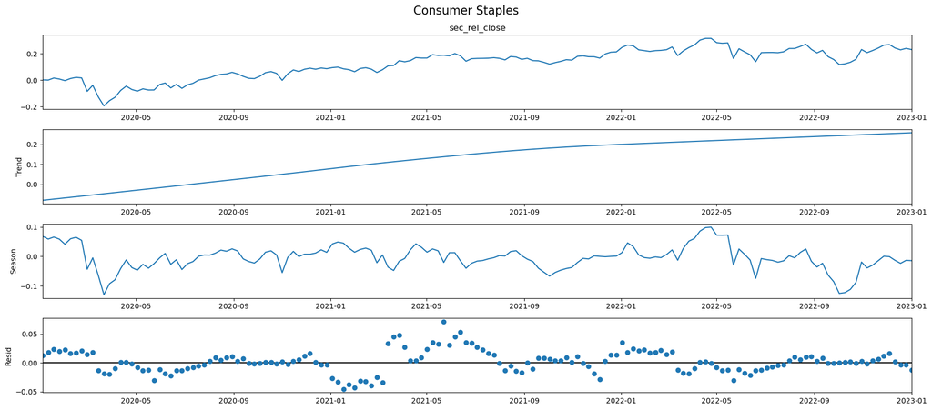

```python
fig = my_decom(sec_df, sectors)[6].plot().suptitle(sectors[6], fontsize=16)
plt.tight_layout()
```

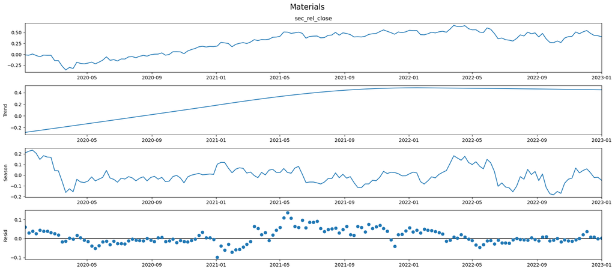

```python
fig = my_decom(sec_df, sectors)[7].plot().suptitle(sectors[7], fontsize=16)
plt.tight_layout()
```

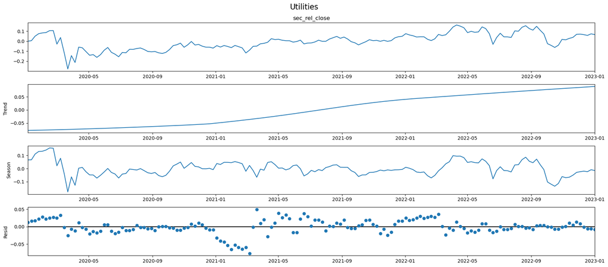

```python
fig = my_decom(sec_df, sectors)[8].plot().suptitle(sectors[8], fontsize=16)
plt.tight_layout()
```

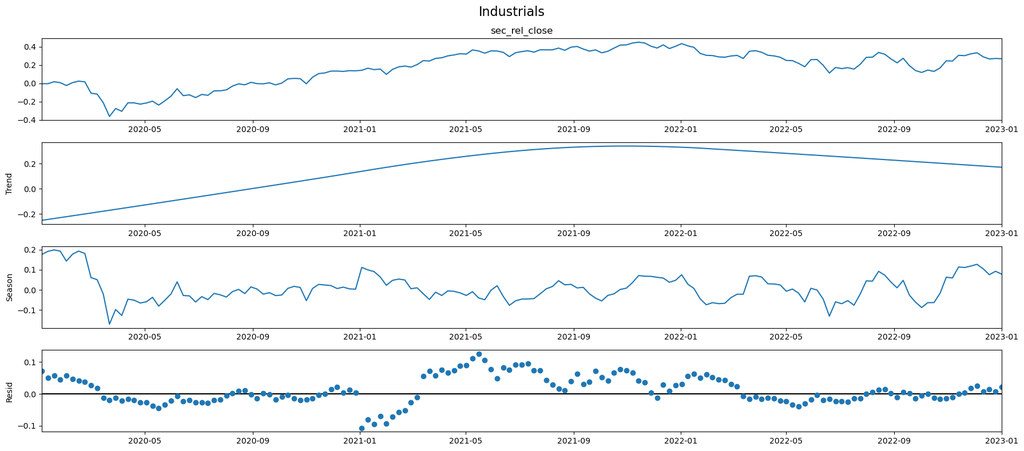

```python
fig = my_decom(sec_df, sectors)[9].plot().suptitle(sectors[9], fontsize=16)
plt.tight_layout()
```

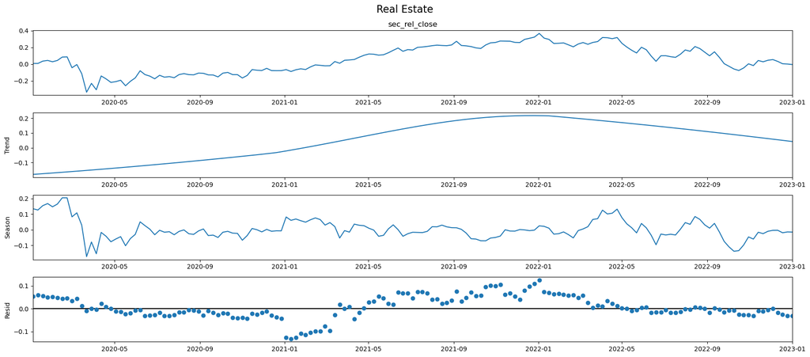

```python
fig = my_decom(sec_df, sectors)[10].plot().suptitle(sectors[10], fontsize=16)
plt.tight_layout()
```

# Decomposition based on each company

**Creating a dataframe for with each company name, and rel closing price**

```python
company_df = lf.groupby(['symbol', 'date_dt']).\
    aggregate(company_rel_close = ('rel_close', 'mean')).\
    reset_index()
```

**Creating a name for each company name**

```python
each_company = lf.symbol.unique()
```

```python
(company_df.symbol == each_company[0]).sum()
```

```
756
```

**Function that creates a dataframe, extracts rel_close_price into series, makes the series ready for time series, resamples the series (weekly) and appends the final results to a list for each company**

```python
def my_each_comp_decom(given_df, given_comp):
    res_list = []
    ready_list=[]

    ### Getting all the sereis ready for decomposition in list
    for i in range(0, len(given_comp)):
        df = given_df.loc[given_df.symbol == given_comp[i]]
        company_close_series = df.company_rel_close.copy()
        company_close_series.index = df.date_dt.copy()
        company_ready_series = company_close_series.copy().resample('W').last()
        res_list.append(company_ready_series)

    ### Using the ready sereis to create a STL decomposition for all companies.
    for i in range(0, len(given_comp)):
        ready_list.append( STL(res_list[i]).fit() )


    return ready_list
```

**Calling the above function and storing the result to a variable.**

```python
comp_decom_res = my_each_comp_decom(company_df, each_company)
```

**Function to create a dataframe for seasonal and trend component values of each company**

```python
def get_trend_seasonal_val(decom_res, given_comp):
    ready_df = pd.DataFrame()

    for i in range(0, len(given_comp)):
        # getting seasonal values
        seasonal_val = decom_res[i].seasonal

        # getting trend values
        trend_val = decom_res[i].trend

        # merging seasonal and trend value for each company
        temp_df = pd.concat([seasonal_val, trend_val], axis=1).reset_index()

        # adding the compnay name to the dataframe
        temp_df['symbol'] = given_comp[i]

        # merging all companies in one dataframe
        ready_df = pd.concat([ready_df, temp_df])

    return ready_df
```

```python
trend_seasonal_df = get_trend_seasonal_val( comp_decom_res, each_company )
```

```python
trend_seasonal_df.info()
```

```
<class 'pandas.core.frame.DataFrame'>
Int64Index: 78500 entries, 0 to 156
Data columns (total 4 columns):
 #   Column   Non-Null Count  Dtype
---  ------   --------------  -----
 0   date_dt  78500 non-null  datetime64[ns]
 1   season   78500 non-null  float64
 2   trend    78500 non-null  float64
 3   symbol   78500 non-null  object
dtypes: datetime64[ns](1), float64(2), object(1)
memory usage: 3.0+ MB
```

```python
trend_seasonal_df
```

|  | date_dt | season | trend | symbol |
| --- | --- | --- | --- | --- |
| 0 | 2020-01-05 | 0.078592 | -0.013662 | AAPL |
| 1 | 2020-01-12 | 0.033156 | -0.001812 | AAPL |
| 2 | 2020-01-19 | 0.022567 | 0.010038 | AAPL |
| 3 | 2020-01-26 | 0.076878 | 0.021886 | AAPL |
| 4 | 2020-02-02 | -0.005416 | 0.033732 | AAPL |
| ... | ... | ... | ... | ... |
| 152 | 2022-12-04 | -0.110797 | 0.174458 | SBNY |
| 153 | 2022-12-11 | -0.205846 | 0.155069 | SBNY |
| 154 | 2022-12-18 | -0.221761 | 0.135612 | SBNY |
| 155 | 2022-12-25 | -0.162053 | 0.116089 | SBNY |
| 156 | 2023-01-01 | -0.170421 | 0.096503 | SBNY |

78500 rows × 4 columns

```python
trend_seasonal_df.symbol.nunique()
```

```
500
```

**Plot representing the seasonal values of Apple.**

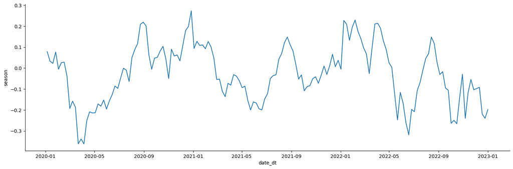

```python
sns.relplot(data=trend_seasonal_df.loc[trend_seasonal_df.symbol=='AAPL'], x='date_dt', y='season', kind='line',
           aspect=3)

plt.show()
```

We can see some patterns here.

```python
search_list = trend_seasonal_df.symbol.unique()[:10]
```

```python
trend_seasonal_df.loc[trend_seasonal_df.symbol.isin(search_list)]
```

|  | date_dt | season | trend | symbol |
| --- | --- | --- | --- | --- |
| 0 | 2020-01-05 | 0.078592 | -0.013662 | AAPL |
| 1 | 2020-01-12 | 0.033156 | -0.001812 | AAPL |
| 2 | 2020-01-19 | 0.022567 | 0.010038 | AAPL |
| 3 | 2020-01-26 | 0.076878 | 0.021886 | AAPL |
| 4 | 2020-02-02 | -0.005416 | 0.033732 | AAPL |
| ... | ... | ... | ... | ... |
| 152 | 2022-12-04 | -0.048995 | 0.874297 | UNH |
| 153 | 2022-12-11 | -0.010221 | 0.880115 | UNH |
| 154 | 2022-12-18 | -0.053013 | 0.885925 | UNH |
| 155 | 2022-12-25 | -0.029709 | 0.891728 | UNH |
| 156 | 2023-01-01 | -0.033320 | 0.897523 | UNH |

1570 rows × 4 columns

**Chcecking out seasonality of few companies.**

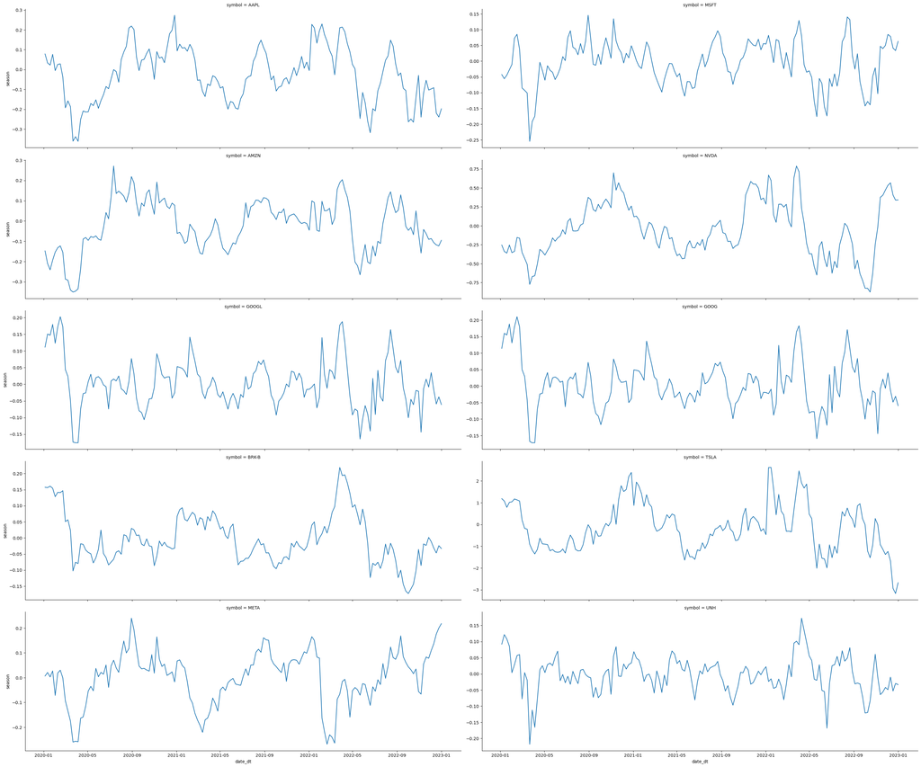

```python
sns.relplot(data=trend_seasonal_df.loc[trend_seasonal_df.symbol.isin(search_list)],
            x='date_dt', y='season', kind='line',
            col='symbol', col_wrap=2,
           aspect=3, facet_kws={'sharey':False})

plt.show()
```

### Pivot the dataframe to create a wide format dataframe for modelling purpose

**Seasonal wide format dataframe**

Extracting just the seasonal values and storing it in a new dataframe.

```python
seasonal_wf = trend_seasonal_df.pivot(index='symbol', columns='date_dt', values='season')
```

**Saving seasonal data**

```python
# seasonal_wf.to_csv('seasonal_wf.csv')
```

**Trend wide format dataframe**

Extracting just the trend values and storing it in a new dataframe.

```python
trend_wf = trend_seasonal_df.pivot(index='symbol', columns='date_dt', values='trend')
```

**Saving Trend data**

```python
# trend_wf.to_csv('trend_wf.csv')
```

**Merging seasonal component with original wf dataframe**

```python
wf_trend_seasonal = wf_final.set_index('symbol').join(seasonal_wf, on='symbol', how='left').reset_index()
```

**Renaming seasonal component columns**

```python
wf_trend_seasonal.columns.values[-157:] = ['seasonal_week_' + str(d).zfill(3) for d in range(1, 157+1)]
```

**Merging trend components with original wf dataframe**

```python
wf_trend_seasonal = wf_trend_seasonal.set_index('symbol').join(trend_wf, on='symbol', how='left').reset_index()
```

**Renaming trend components**

```python
wf_trend_seasonal.columns.values[-157:] = ['trend_week_' + str(d).zfill(3) for d in range(1, 157+1)]
```

```python
wf_trend_seasonal.head()
```

| date_dt | symbol | day_001 | day_002 | day_003 | day_004 | day_005 | day_006 | day_007 | day_008 | day_009 | ... | trend_week_148 | trend_week_149 | trend_week_150 | trend_week_151 | trend_week_152 | trend_week_153 | trend_week_154 | trend_week_155 | trend_week_156 | trend_week_157 |
| --- | --- | --- | --- | --- | --- | --- | --- | --- | --- | --- | --- | --- | --- | --- | --- | --- | --- | --- | --- | --- | --- |
| 0 | A | 0.0 | -0.016056 | -0.013147 | -0.010122 | -0.000349 | 0.015358 | 0.019081 | 0.017568 | 0.023735 | ... | 0.427623 | 0.421630 | 0.415636 | 0.409641 | 0.403647 | 0.397654 | 0.391663 | 0.385674 | 0.379689 | 0.373707 |
| 1 | AAL | 0.0 | -0.049502 | -0.060846 | -0.064283 | -0.042970 | -0.039189 | -0.060846 | -0.058439 | -0.053627 | ... | -0.584738 | -0.589755 | -0.594768 | -0.599776 | -0.604779 | -0.609777 | -0.614770 | -0.619756 | -0.624736 | -0.629710 |
| 2 | AAP | 0.0 | 0.000063 | -0.016373 | -0.028041 | -0.039207 | -0.041026 | -0.065241 | -0.088765 | -0.065931 | ... | 0.110821 | 0.105222 | 0.099597 | 0.093946 | 0.088271 | 0.082572 | 0.076849 | 0.071102 | 0.065333 | 0.059542 |
| 3 | AAPL | 0.0 | -0.009722 | -0.001831 | -0.006526 | 0.009456 | 0.030897 | 0.033228 | 0.055302 | 0.041052 | ... | 1.095322 | 1.095637 | 1.095928 | 1.096195 | 1.096437 | 1.096656 | 1.096849 | 1.097019 | 1.097163 | 1.097284 |
| 4 | ABBV | 0.0 | -0.009492 | -0.001675 | -0.007370 | -0.000335 | 0.007370 | -0.005472 | -0.011502 | -0.015075 | ... | 0.800774 | 0.808546 | 0.816319 | 0.824093 | 0.831868 | 0.839644 | 0.847422 | 0.855201 | 0.862980 | 0.870761 |

5 rows × 1072 columns

**Saving the original wide format data frame with seasonal and trend values.**

```python
# wf_trend_seasonal.to_csv('wf_final_df.csv')
```

### Creating Monthly Dataframe

**Creating the same dataframe as above but instead on weekly time series we will resample monthly just for the sake of less computing while modelling with the seasonal and trend values**

**Same decoomposition function as above just the resampling value is changed.**

```python
def my_each_comp_decom_month_end(given_df, given_comp):
    res_list = []
    ready_list=[]

    ### Getting all the sereis ready for decomposition in list
    for i in range(0, len(given_comp)):
        df = given_df.loc[given_df.symbol == given_comp[i]]
        company_close_series = df.company_rel_close.copy()
        company_close_series.index = df.date_dt.copy()
        ### changing the resampling value to month end M
        company_ready_series = company_close_series.copy().resample('M').last()
        res_list.append(company_ready_series)

    ### Using the ready sereis to create a STL decomposition for all companies.
    for i in range(0, len(given_comp)):
        ready_list.append( STL(res_list[i]).fit() )


    return ready_list
```

```python
comp_decom_res_month_end = my_each_comp_decom_month_end(company_df, each_company)
```

**Pulling the trend and seasonal values form the decomposition**

```python
trend_seasonal_month_end_df = get_trend_seasonal_val( comp_decom_res_month_end, each_company )
```

```python
trend_seasonal_month_end_df
```

|  | date_dt | season | trend | symbol |
| --- | --- | --- | --- | --- |
| 0 | 2020-01-31 | -0.047186 | 0.080722 | AAPL |
| 1 | 2020-02-29 | -0.225718 | 0.126550 | AAPL |
| 2 | 2020-03-31 | -0.348600 | 0.172463 | AAPL |
| 3 | 2020-04-30 | -0.219815 | 0.218477 | AAPL |
| 4 | 2020-05-31 | -0.215263 | 0.264596 | AAPL |
| ... | ... | ... | ... | ... |
| 31 | 2022-08-31 | -0.131713 | 0.391784 | SBNY |
| 32 | 2022-09-30 | -0.165030 | 0.305760 | SBNY |
| 33 | 2022-10-31 | 0.015576 | 0.218199 | SBNY |
| 34 | 2022-11-30 | -0.044573 | 0.129210 | SBNY |
| 35 | 2022-12-31 | -0.084445 | 0.038925 | SBNY |

18000 rows × 4 columns

**Pivot the seasonal values**

```python
seasonal_month_end_wf = trend_seasonal_month_end_df.pivot(index='symbol', columns='date_dt', values='season')
```

**Pivot the trend values**

```python
trend_month_end_wf = trend_seasonal_month_end_df.pivot(index='symbol', columns='date_dt', values='trend')
```

**Merging monthly seasonal values with original dataframe**

```python
wf_month_ts = wf.set_index('symbol').join(seasonal_month_end_wf, on='symbol', how='left').reset_index()
```

**Renaming the monthly seasoanl components**

```python
wf_month_ts.columns.values[-36:] = ['seasonal_month_' + str(d).zfill(2) for d in range(1, 36+1)]
```

**Merging monthly trend values with original dataframe**

```python
wf_month_ts = wf_month_ts.set_index('symbol').join(trend_month_end_wf, on='symbol', how='left').reset_index()
```

**Renaming the monthly trend components**

```python
wf_month_ts.columns.values[-36:] = ['trend_month_' + str(d).zfill(2) for d in range(1, 36+1)]
```

```python
wf_month_ts.head()
```

|  | symbol | sector | day_001 | day_002 | day_003 | day_004 | day_005 | day_006 | day_007 | day_008 | ... | trend_month_27 | trend_month_28 | trend_month_29 | trend_month_30 | trend_month_31 | trend_month_32 | trend_month_33 | trend_month_34 | trend_month_35 | trend_month_36 |
| --- | --- | --- | --- | --- | --- | --- | --- | --- | --- | --- | --- | --- | --- | --- | --- | --- | --- | --- | --- | --- | --- |
| 0 | A | Health Care | 85.949997 | 84.570000 | 84.820000 | 85.080002 | 85.919998 | 87.269997 | 87.589996 | 87.459999 | ... | 0.604990 | 0.580574 | 0.556088 | 0.531426 | 0.506563 | 0.481515 | 0.456322 | 0.431061 | 0.405818 | 0.380666 |
| 1 | AAL | Industrials | 29.090000 | 27.650000 | 27.320000 | 27.219999 | 27.840000 | 27.950001 | 27.320000 | 27.389999 | ... | -0.429044 | -0.450414 | -0.471881 | -0.493465 | -0.515138 | -0.536860 | -0.558588 | -0.580283 | -0.601906 | -0.623424 |
| 2 | AAP | Consumer Discretionary | 159.410004 | 159.419998 | 156.800003 | 154.940002 | 153.160004 | 152.869995 | 149.009995 | 145.259995 | ... | 0.250616 | 0.226378 | 0.201421 | 0.175775 | 0.149492 | 0.122630 | 0.095237 | 0.067347 | 0.038987 | 0.010184 |
| 3 | AAPL | Information Technology | 75.087502 | 74.357498 | 74.949997 | 74.597504 | 75.797501 | 77.407501 | 77.582497 | 79.239998 | ... | 1.089546 | 1.090886 | 1.091451 | 1.091331 | 1.090597 | 1.089314 | 1.087520 | 1.085224 | 1.082415 | 1.079081 |
| 4 | ABBV | Health Care | 89.550003 | 88.699997 | 89.400002 | 88.889999 | 89.519997 | 90.209999 | 89.059998 | 88.519997 | ... | 0.553235 | 0.585158 | 0.617144 | 0.649166 | 0.681206 | 0.713246 | 0.745279 | 0.777318 | 0.809378 | 0.841474 |

5 rows × 830 columns